# Investigating a dataset by Bidish Basu

```
##   X fixed.acidity volatile.acidity citric.acid residual.sugar chlorides
## 1 1           7.4             0.70        0.00            1.9     0.076
## 2 2           7.8             0.88        0.00            2.6     0.098
## 3 3           7.8             0.76        0.04            2.3     0.092
## 4 4          11.2             0.28        0.56            1.9     0.075
## 5 5           7.4             0.70        0.00            1.9     0.076
## 6 6           7.4             0.66        0.00            1.8     0.075
##   free.sulfur.dioxide total.sulfur.dioxide density   pH sulphates alcohol
## 1                  11                   34  0.9978 3.51      0.56     9.4
## 2                  25                   67  0.9968 3.20      0.68     9.8
## 3                  15                   54  0.9970 3.26      0.65     9.8
## 4                  17                   60  0.9980 3.16      0.58     9.8
## 5                  11                   34  0.9978 3.51      0.56     9.4
## 6                  13                   40  0.9978 3.51      0.56     9.4
##   quality
## 1       5
## 2       5
## 3       5
## 4       6
## 5       5
## 6       5
```

In this project, I will be exploring the “wineQualityReds.csv” dataset.

# Univariate Plots Section

```
##        X          fixed.acidity   volatile.acidity  citric.acid
##  Min.   :   1.0   Min.   : 4.60   Min.   :0.1200   Min.   :0.000
##  1st Qu.: 400.5   1st Qu.: 7.10   1st Qu.:0.3900   1st Qu.:0.090
##  Median : 800.0   Median : 7.90   Median :0.5200   Median :0.260
##  Mean   : 800.0   Mean   : 8.32   Mean   :0.5278   Mean   :0.271
##  3rd Qu.:1199.5   3rd Qu.: 9.20   3rd Qu.:0.6400   3rd Qu.:0.420
##  Max.   :1599.0   Max.   :15.90   Max.   :1.5800   Max.   :1.000
##  residual.sugar     chlorides       free.sulfur.dioxide
##  Min.   : 0.900   Min.   :0.01200   Min.   : 1.00
##  1st Qu.: 1.900   1st Qu.:0.07000   1st Qu.: 7.00
##  Median : 2.200   Median :0.07900   Median :14.00
##  Mean   : 2.539   Mean   :0.08747   Mean   :15.87
##  3rd Qu.: 2.600   3rd Qu.:0.09000   3rd Qu.:21.00
##  Max.   :15.500   Max.   :0.61100   Max.   :72.00
##  total.sulfur.dioxide    density             pH          sulphates
##  Min.   :  6.00       Min.   :0.9901   Min.   :2.740   Min.   :0.3300
##  1st Qu.: 22.00       1st Qu.:0.9956   1st Qu.:3.210   1st Qu.:0.5500
##  Median : 38.00       Median :0.9968   Median :3.310   Median :0.6200
##  Mean   : 46.47       Mean   :0.9967   Mean   :3.311   Mean   :0.6581
##  3rd Qu.: 62.00       3rd Qu.:0.9978   3rd Qu.:3.400   3rd Qu.:0.7300
##  Max.   :289.00       Max.   :1.0037   Max.   :4.010   Max.   :2.0000
##     alcohol         quality
##  Min.   : 8.40   Min.   :3.000
##  1st Qu.: 9.50   1st Qu.:5.000
##  Median :10.20   Median :6.000
##  Mean   :10.42   Mean   :5.636
##  3rd Qu.:11.10   3rd Qu.:6.000
##  Max.   :14.90   Max.   :8.000
```

```
##   fixed.acidity volatile.acidity citric.acid residual.sugar chlorides
## 1           7.4             0.70        0.00            1.9     0.076
## 2           7.8             0.88        0.00            2.6     0.098
## 3           7.8             0.76        0.04            2.3     0.092
## 4          11.2             0.28        0.56            1.9     0.075
## 5           7.4             0.70        0.00            1.9     0.076
## 6           7.4             0.66        0.00            1.8     0.075
##   free.sulfur.dioxide total.sulfur.dioxide density   pH sulphates alcohol
## 1                  11                   34  0.9978 3.51      0.56     9.4
## 2                  25                   67  0.9968 3.20      0.68     9.8
## 3                  15                   54  0.9970 3.26      0.65     9.8
## 4                  17                   60  0.9980 3.16      0.58     9.8
## 5                  11                   34  0.9978 3.51      0.56     9.4
## 6                  13                   40  0.9978 3.51      0.56     9.4
##   quality
## 1       5
## 2       5
## 3       5
## 4       6
## 5       5
## 6       5
```

```
## 'data.frame':    1599 obs. of  12 variables:
##  $ fixed.acidity       : num  7.4 7.8 7.8 11.2 7.4 7.4 7.9 7.3 7.8 7.5 ...
##  $ volatile.acidity    : num  0.7 0.88 0.76 0.28 0.7 0.66 0.6 0.65 0.58 0.5 ...
##  $ citric.acid         : num  0 0 0.04 0.56 0 0 0.06 0 0.02 0.36 ...
##  $ residual.sugar      : num  1.9 2.6 2.3 1.9 1.9 1.8 1.6 1.2 2 6.1 ...
##  $ chlorides           : num  0.076 0.098 0.092 0.075 0.076 0.075 0.069 0.065 0.073 0.071 ...
##  $ free.sulfur.dioxide : num  11 25 15 17 11 13 15 15 9 17 ...
##  $ total.sulfur.dioxide: num  34 67 54 60 34 40 59 21 18 102 ...
##  $ density             : num  0.998 0.997 0.997 0.998 0.998 ...
##  $ pH                  : num  3.51 3.2 3.26 3.16 3.51 3.51 3.3 3.39 3.36 3.35 ...
##  $ sulphates           : num  0.56 0.68 0.65 0.58 0.56 0.56 0.46 0.47 0.57 0.8 ...
##  $ alcohol             : num  9.4 9.8 9.8 9.8 9.4 9.4 9.4 10 9.5 10.5 ...
##  $ quality             : int  5 5 5 6 5 5 5 7 7 5 ...
```

Here are my observations from the prelimnary analysis,

1. There are 1599 rows and 13 columns.
2. I have removed the column named “X” as it was not of much importance to my analysis after which I am left with 1599 rows and 12 columns.
3. As per the information given about the dataset, the variable “quality” catches my eye, as it is a categorical variable which will help me in my analysis.

Since “quality” is my main focus here, I will be creating a new variable to further simplify the way the quality of the wine is assessed. I am going to divide the dataset based on the quality rating,as follows

1. If the quality is rated between 0 to 4 then its “low”
2. If the quality is rated between 5 to 7 then its “medium”
3. If the quality is rated above 7 then its “high”

```
##   fixed.acidity volatile.acidity citric.acid residual.sugar chlorides
## 1           7.4             0.70        0.00            1.9     0.076
## 2           7.8             0.88        0.00            2.6     0.098
## 3           7.8             0.76        0.04            2.3     0.092
## 4          11.2             0.28        0.56            1.9     0.075
## 5           7.4             0.70        0.00            1.9     0.076
## 6           7.4             0.66        0.00            1.8     0.075
##   free.sulfur.dioxide total.sulfur.dioxide density   pH sulphates alcohol
## 1                  11                   34  0.9978 3.51      0.56     9.4
## 2                  25                   67  0.9968 3.20      0.68     9.8
## 3                  15                   54  0.9970 3.26      0.65     9.8
## 4                  17                   60  0.9980 3.16      0.58     9.8
## 5                  11                   34  0.9978 3.51      0.56     9.4
## 6                  13                   40  0.9978 3.51      0.56     9.4
##   quality wine_rating
## 1       5      medium
## 2       5      medium
## 3       5      medium
## 4       6      medium
## 5       5      medium
## 6       5      medium
```

We see that a new column has been added to the dataset called “wine_rating” where the wines are rated as “high”,“medium” and “low” based on their quality.

I am converting the “quality” and “wine_rating” variables to factors.

```
## 'data.frame':    1599 obs. of  13 variables:
##  $ fixed.acidity       : num  7.4 7.8 7.8 11.2 7.4 7.4 7.9 7.3 7.8 7.5 ...
##  $ volatile.acidity    : num  0.7 0.88 0.76 0.28 0.7 0.66 0.6 0.65 0.58 0.5 ...
##  $ citric.acid         : num  0 0 0.04 0.56 0 0 0.06 0 0.02 0.36 ...
##  $ residual.sugar      : num  1.9 2.6 2.3 1.9 1.9 1.8 1.6 1.2 2 6.1 ...
##  $ chlorides           : num  0.076 0.098 0.092 0.075 0.076 0.075 0.069 0.065 0.073 0.071 ...
##  $ free.sulfur.dioxide : num  11 25 15 17 11 13 15 15 9 17 ...
##  $ total.sulfur.dioxide: num  34 67 54 60 34 40 59 21 18 102 ...
##  $ density             : num  0.998 0.997 0.997 0.998 0.998 ...
##  $ pH                  : num  3.51 3.2 3.26 3.16 3.51 3.51 3.3 3.39 3.36 3.35 ...
##  $ sulphates           : num  0.56 0.68 0.65 0.58 0.56 0.56 0.46 0.47 0.57 0.8 ...
##  $ alcohol             : num  9.4 9.8 9.8 9.8 9.4 9.4 9.4 10 9.5 10.5 ...
##  $ quality             : Factor w/ 6 levels "3","4","5","6",..: 3 3 3 4 3 3 3 5 5 3 ...
##  $ wine_rating         : Factor w/ 3 levels "high","low","medium": 3 3 3 3 3 3 3 3 3 3 ...
```

```
##
##   3   4   5   6   7   8
##  10  53 681 638 199  18
```

We see that quality has been converted to a factor with 6 levels ranging from 3-8

```
##
##   high    low medium
##     18     63   1518
```

We see that wine_rating has been converted to a factor with 3 levels.

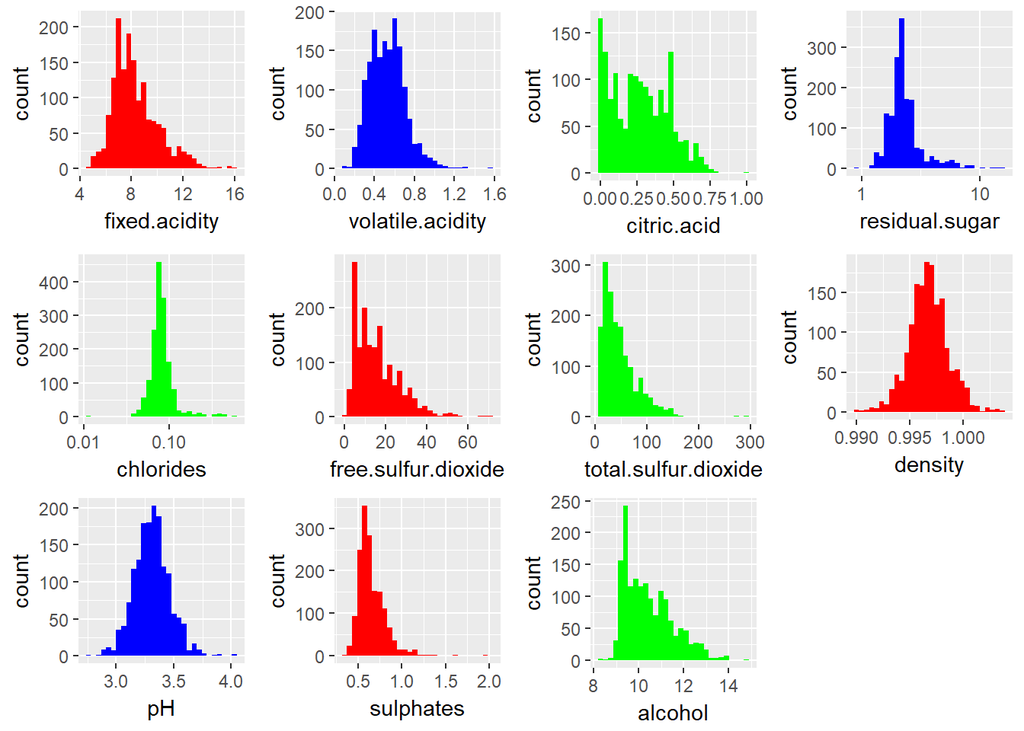

We see from the histograms that, 1. Density and pH are normally distributed. 2. Fixed and volatile acidity,sulphates,alcohol,chlorides,residual sugar are long tailed.

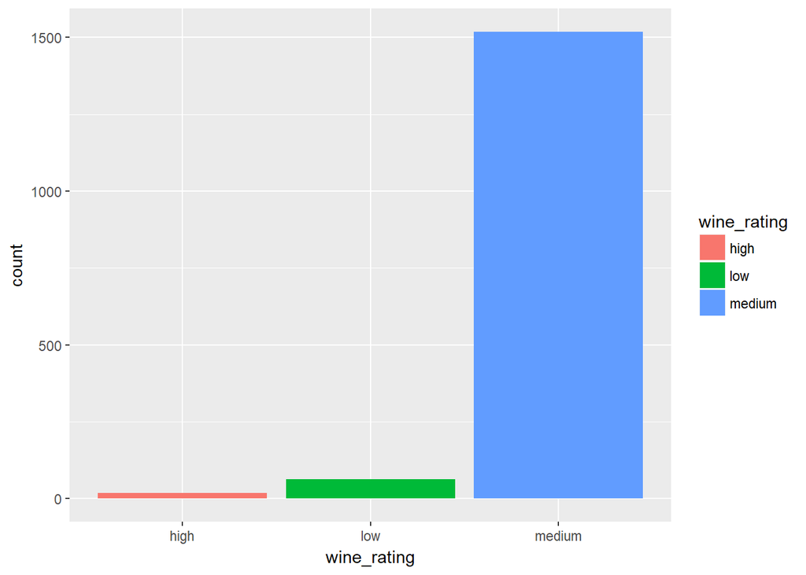

We see that as per the ratings, we have a large amount of wine that have quality between 5-7 as compared to ones below 5 and above 7 which are quite small in number.

# Univariate Analysis

### What is the structure of your dataset?

There are 1599 observations in the dataset with 13 variables.

The 13 features and their short description is as follows:

Fixed acidity: most acids involved with wine or fixed or nonvolatile (do not evaporate readily)

Volatile acidity: the amount of acetic acid in wine.

Citric acid: mostly used for adding flavor.

Residual sugar: the amount of sugar remaining after fermentation stops and measured in gms of sugar per liter.

Chlorides: the amount of salt in the wine.

Free sulfur dioxide: the free form of SO2 exists in equilibrium between molecular SO2 (as a dissolved gas) and bisulfite ion; it prevents microbial growth and the oxidation of wine.

Total sulfur dioxide: amount of free and bound forms of S02.

Density: the density of water is close to that of water depending on the percent alcohol and sugar content.

pH: describes how acidic or basic a wine is on a scale from 0 (very acidic) to 14 (very basic); most wines are between 3-4 on the pH scale.

Sulphates: a wine additive which can contribute to sulfur dioxide gas (S02) levels, which acts as an antimicrobial and antioxidant.

Alcohol: the percent alcohol present in the wine.

Quality: rating of the wine between 0-10 in the given sample

wine_rating: rating of wine as high,medium,low.

### What is/are the main feature(s) of interest in your dataset?

The main feature that intrests me is the quality of the wine.

### What other features in the dataset do you think will help support your investigation into your feature(s) of interest?

Features like fixed and volatile acidity, sulfur dioxide, alcohol and pH are interesting as well.

### Did you create any new variables from existing variables in the dataset?

I found citic acid to be very unusually distributed. But since that is not of importance to my investigation, I have not tidied it up.

# Bivariate Plots Section

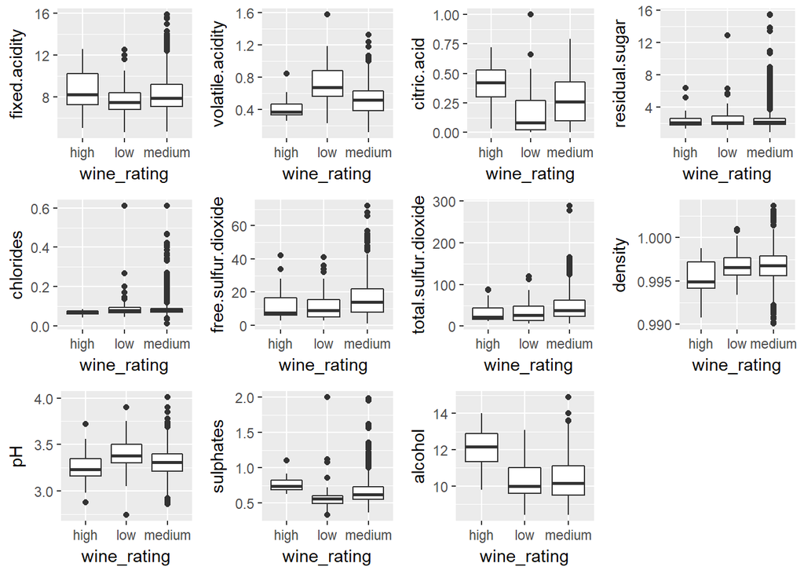

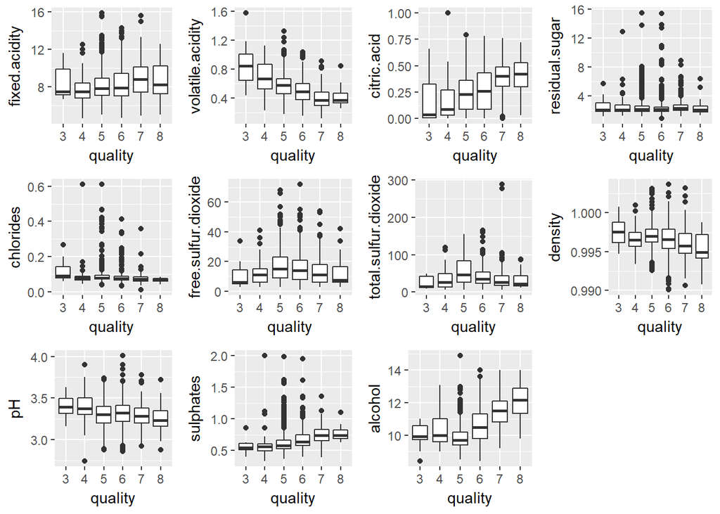

When we plot a similar plot using “quality”, the wines that are rated between 4-7 have high outliers.

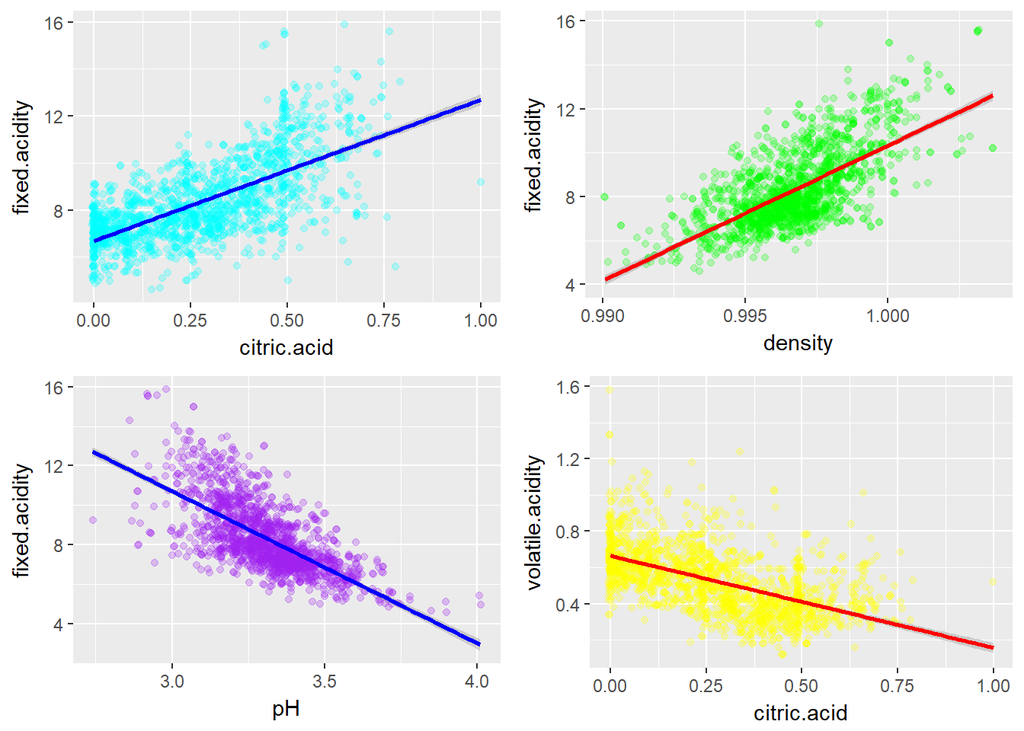

We see that, there are strong positive correlations between fixed acidity and density and citric acid.

Similarly, we see that there is a strong negative correlation between fixed acidity and pH also with volatile acid and ctric acid.

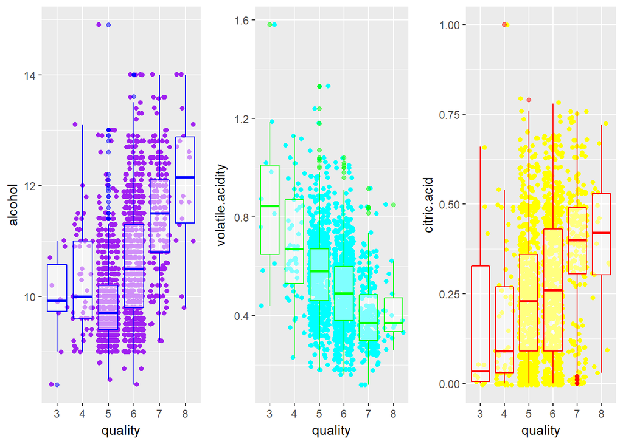

From the box plots above, we see that, alcohol and ctric acid have strong positive correlations with quality and volatile acid has a strong negative correlation.

```
##                      fixed.acidity volatile.acidity citric.acid
## fixed.acidity           1.00000000     -0.256130895  0.67170343
## volatile.acidity       -0.25613089      1.000000000 -0.55249568
## citric.acid             0.67170343     -0.552495685  1.00000000
## residual.sugar          0.11477672      0.001917882  0.14357716
## chlorides               0.09370519      0.061297772  0.20382291
## free.sulfur.dioxide    -0.15379419     -0.010503827 -0.06097813
## total.sulfur.dioxide   -0.11318144      0.076470005  0.03553302
## density                 0.66804729      0.022026232  0.36494718
## pH                     -0.68297819      0.234937294 -0.54190414
## sulphates               0.18300566     -0.260986685  0.31277004
## alcohol                -0.06166827     -0.202288027  0.10990325
##                      residual.sugar    chlorides free.sulfur.dioxide
## fixed.acidity           0.114776724  0.093705186        -0.153794193
## volatile.acidity        0.001917882  0.061297772        -0.010503827
## citric.acid             0.143577162  0.203822914        -0.060978129
## residual.sugar          1.000000000  0.055609535         0.187048995
## chlorides               0.055609535  1.000000000         0.005562147
## free.sulfur.dioxide     0.187048995  0.005562147         1.000000000
## total.sulfur.dioxide    0.203027882  0.047400468         0.667666450
## density                 0.355283371  0.200632327        -0.021945831
## pH                     -0.085652422 -0.265026131         0.070377499
## sulphates               0.005527121  0.371260481         0.051657572
## alcohol                 0.042075437 -0.221140545        -0.069408354
##                      total.sulfur.dioxide     density          pH
## fixed.acidity                 -0.11318144  0.66804729 -0.68297819
## volatile.acidity               0.07647000  0.02202623  0.23493729
## citric.acid                    0.03553302  0.36494718 -0.54190414
## residual.sugar                 0.20302788  0.35528337 -0.08565242
## chlorides                      0.04740047  0.20063233 -0.26502613
## free.sulfur.dioxide            0.66766645 -0.02194583  0.07037750
## total.sulfur.dioxide           1.00000000  0.07126948 -0.06649456
## density                        0.07126948  1.00000000 -0.34169933
## pH                            -0.06649456 -0.34169933  1.00000000
## sulphates                      0.04294684  0.14850641 -0.19664760
## alcohol                       -0.20565394 -0.49617977  0.20563251
##                         sulphates     alcohol
## fixed.acidity         0.183005664 -0.06166827
## volatile.acidity     -0.260986685 -0.20228803
## citric.acid           0.312770044  0.10990325
## residual.sugar        0.005527121  0.04207544
## chlorides             0.371260481 -0.22114054
## free.sulfur.dioxide   0.051657572 -0.06940835
## total.sulfur.dioxide  0.042946836 -0.20565394
## density               0.148506412 -0.49617977
## pH                   -0.196647602  0.20563251
## sulphates             1.000000000  0.09359475
## alcohol               0.093594750  1.00000000
```

# Bivariate Analysis

### Talk about some of the relationships you observed in this part of the investigation. How did the feature(s) of interest vary with other features in the dataset?

Scatterplots and boxplots showed strong positive correlation of alcohol with quality and strong negative correlation between volatile acidity and quality.

So, we infer that good wine generally has higher alcohol content,higher citric acidity and lower volatile acidity.

### Did you observe any interesting relationships between the other features (not the main feature(s) of interest)?

We see some strong correlations as follows,

Fixed acidity vs citric acid (0.67)

Volatile acidity vs citric acid (-0.55)

Fixed acidity vs density (0.67)

Fixed acidity vs pH (-0.68)

### What was the strongest relationship you found?

pH and fixed acidity showed a strong negative correlation(-68%)

# Multivariate Plots Section

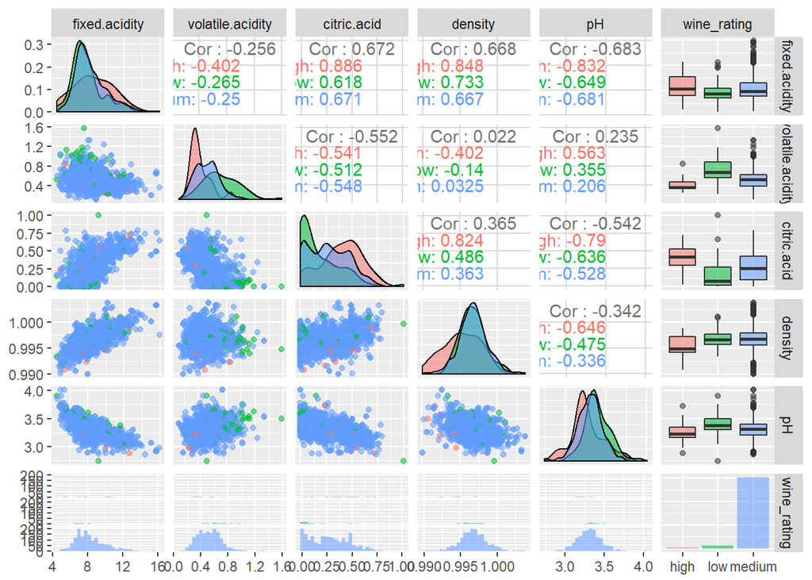

# Multivariate Analysis

### Talk about some of the relationships you observed in this part of the investigation. Were there features that strengthened each other in terms of looking at your feature(s) of interest?

Good quality wines tend to have higher citric acid and lower volatile acidity levels. To predict the quality of the wines we can use Alcohol, citric acid, volatile acidity,sulphates to create a linear model. pH according to my my reserach plays a big role in determinig the quality of wine. But the sample given does not seem to be indicative of that.

### Were there any interesting or surprising interactions between features?

One of the surprising aspects of my analysis is that the pH did not really have a significant role to play in determining wine quality. As such most good wines have pH between 3-4.

### OPTIONAL: Did you create any models with your dataset? Discuss the strengths and limitations of your model.

As I have stated in the previous section, pH should have played an important role in determinig the quality of the wines but the sample data is not indicative of the same. From the previous sections we see that the pH levels as per the box plots generated are almost the same for the highand medium quality wines.

# Final Plots and Summary

### Plot One

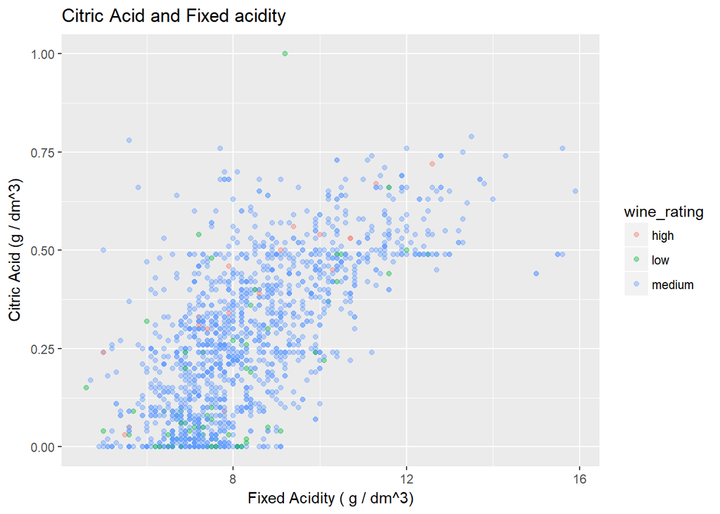

### Plot Two

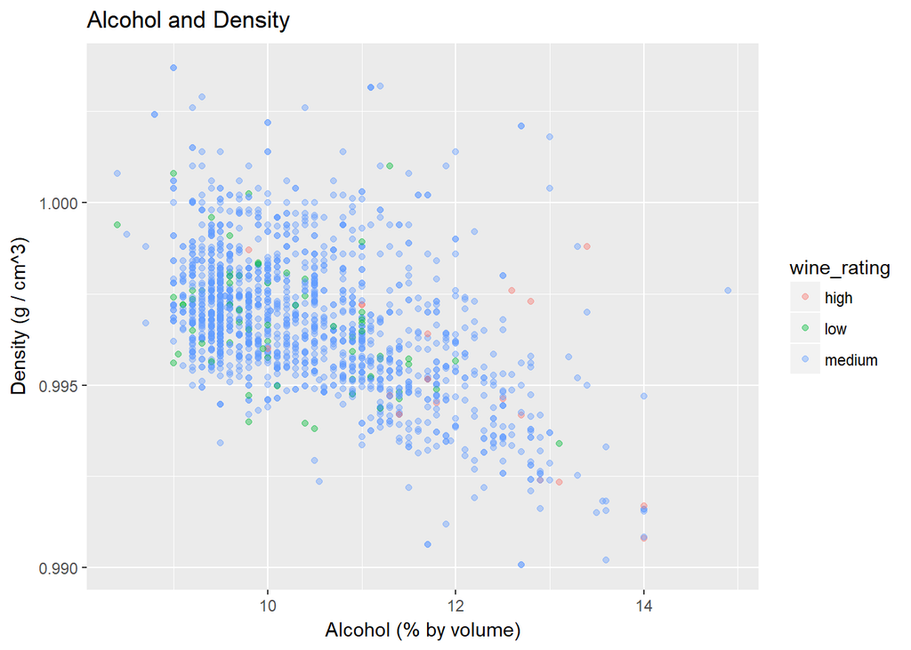

### Description Two

Alcohol and density also play an important role in determinig the quality of the wine. From the plot we see that higher the quality of wine, higher is the alcohol and lower is the density.

### Plot Three

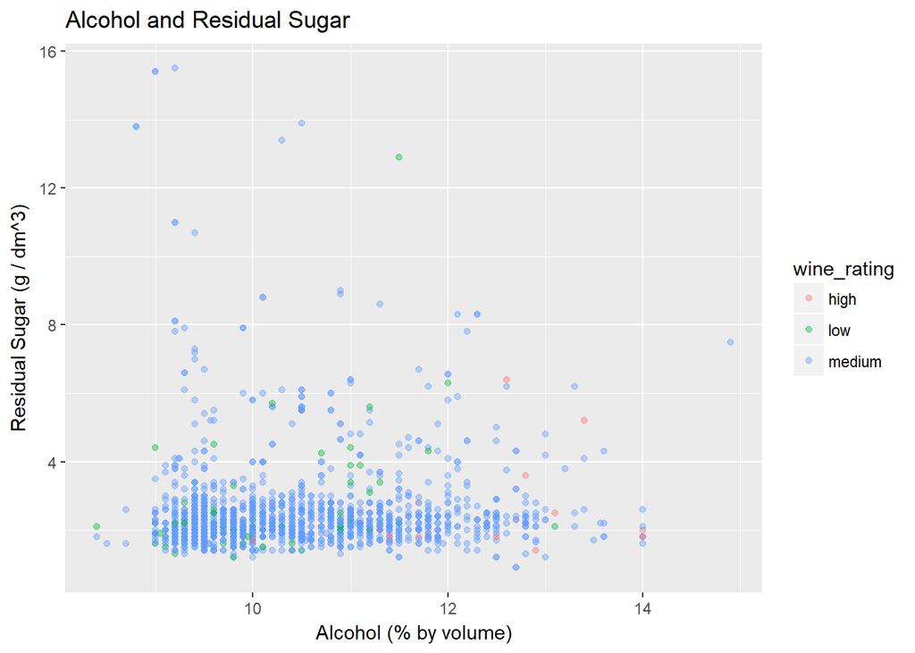

### Description Three

From the plot above, we see that, high quality wines have low amounts of residual sugar and high amounts of alcohol.

# Reflection

In this analysis, my main struggle was to find the factors that are responsible for the production of different quality of wines especially the ‘high’ and the ‘low’ ones. As the data was very centralized towards the ‘medium’ quality. So maybe in future, I can get a dataset about Red Wines with more complete information so that I can build my models more effectively. I was happy to see that the ‘high’ quality wines have high amounts of alcohol and low amounts of residual sugar and volatile acids. For future analysis, I would love to have a dataset, where a rank is given for that particular wine by a number of different wine tasters. This is because, when we include the human element, we get multiple opinions so by including the human element in my analysis, I would be able to have a better understanding of the quality of wine. Having these factors included inside the dataset would result in a different insight altogether in my analysis.